# P5 - Convolutioneel neuraal netwerk

## Import modules

```python
import numpy as np
import matplotlib.pyplot as plt
from tensorflow.keras.datasets import cifar10
from tensorflow.keras.models import Sequential
from tensorflow.keras.layers import Conv2D, MaxPooling2D, Flatten, Dense, Dropout
from tensorflow.keras.utils import to_categorical
```

[output not shown]

## Load the CIFAR-10 dataset

```python
(x_train, y_train), (x_test, y_test) = cifar10.load_data()
```

## Prepare data

```python
x_train = x_train.astype("float32") / 255
x_test = x_test.astype("float32") / 255

y_train = to_categorical(y_train, num_classes=10)
y_test = to_categorical(y_test, num_classes=10)
```

## Build Convolutional Neural Network

### Input shape

De `input_shape` is (32, 32, 3) omdat dit staat voor de grootte van de input(32x32 foto's) en de 3 kleurkanalen (RGB).

### Max pooling laag

- 2x2: Dit convert 4 inputs naar 1. Dit maakt het netwerk sneller, maar met verlies van precisie.

### Tweede en derde convolutionele laag

- 64/128 filters: De filters worden steeds groter, omdat er op hogere niveaus meer complexe kenmerken vastgelegd willen worden.

### Tweede en derde pooling laag

- Er wordt steeds weer pooling toegepast om het model sneller te maken.

### Flatten

- Dit maakt van de outputs een 1D vector, wat makkelijker is om mee te werken.

### Dense

- 512 neurons: Dense maakt een neurale netwerk, met in dit geval 512 neurons. 512 wordt gekozen omdat er nog best veel informatie is, maar meer dan dat is ook niet nodig.

### Dropout

- Dit wordt gebruikt om 0.5 (50%) van de neurons naar 0 te zetten. Dit voorkomt overfitting, omdat als dit niet gedaan wordt het model afhankelijk kan worden van specifieke neurons.

### Dense 2 (output laag)

- 10 neurons: Er zijn 10 klassen in de CIFAR-10 dataset, daarom ook 10 neurons in de output laag.

### Compilatie

- `categorical_crossentropy`: Dit wordt vaak gebruikt voor multi-class classificatie, zoals CIFAR-10, waar de input behoort tot 1 van meerdere klasses.
- Adam: Adam (Adaptive Moment Estimation) is een veel gebruikte optimizer die de learning rate aanpast gebaseerd op de gradients.

```python
model = Sequential()

model.add(Conv2D(32, (3, 3), activation='relu', input_shape=(32, 32, 3)))
model.add(MaxPooling2D(pool_size=(2, 2)))

model.add(Conv2D(64, (3, 3), activation='relu'))
model.add(MaxPooling2D(pool_size=(2, 2)))

model.add(Conv2D(128, (3, 3), activation='relu'))
model.add(MaxPooling2D(pool_size=(2, 2)))

model.add(Flatten())
model.add(Dense(512, activation='relu'))
model.add(Dropout(0.5))
model.add(Dense(10, activation='softmax'))

model.compile(loss='categorical_crossentropy', optimizer='adam', metrics=['accuracy'])
```

## Train model

### Epochs

- 10: Er is gekozen voor 10 epochs omdat meer dan 10 last heeft van overfitting. Zo is bij 50 epochs de accuracy 72%, terwijl dit bij 10 epochs 73% is.

### Batch size

- Kleine batch size (64): Er is gekozen voor een kleine batch size omdat dit problemen zoals overfitting omzeilt. Het nadeel is dat grotere batch sizes veel stabieler gradients krijgen.

```python
# accuracy 50 epochts = ~0.72, 10 epochs = ~0.73
history = model.fit(x_train, y_train, epochs=10, batch_size=64, validation_data=(x_test, y_test))

loss, accuracy = model.evaluate(x_test, y_test)
print(f'Test Loss: {loss:.4f}, Test Accuracy: {accuracy:.4f}')
```

```
2025-03-21 06:23:38.640617: W external/local_tsl/tsl/framework/cpu_allocator_impl.cc:83] Allocation of 614400000 exceeds 10% of free system memory.
2025-03-21 06:23:39.071530: W external/local_tsl/tsl/framework/cpu_allocator_impl.cc:83] Allocation of 614400000 exceeds 10% of free system memory.
```

[output not shown]

```
 30/782 ━━━━━━━━━━━━━━━━━━━━ 4s 5ms/step - accuracy: 0.1255 - loss: 2.2764
```

[output not shown]

```
782/782 ━━━━━━━━━━━━━━━━━━━━ 0s 12ms/step - accuracy: 0.3196 - loss: 1.8222
```

[output not shown]

```
782/782 ━━━━━━━━━━━━━━━━━━━━ 15s 15ms/step - accuracy: 0.3197 - loss: 1.8219 - val_accuracy: 0.5525 - val_loss: 1.2433
782/782 ━━━━━━━━━━━━━━━━━━━━ 5s 6ms/step - accuracy: 0.5528 - loss: 1.2491 - val_accuracy: 0.6196 - val_loss: 1.0630
782/782 ━━━━━━━━━━━━━━━━━━━━ 5s 6ms/step - accuracy: 0.6318 - loss: 1.0451 - val_accuracy: 0.6659 - val_loss: 0.9544
782/782 ━━━━━━━━━━━━━━━━━━━━ 5s 6ms/step - accuracy: 0.6738 - loss: 0.9271 - val_accuracy: 0.6900 - val_loss: 0.8901
782/782 ━━━━━━━━━━━━━━━━━━━━ 5s 6ms/step - accuracy: 0.7112 - loss: 0.8309 - val_accuracy: 0.6999 - val_loss: 0.8577
782/782 ━━━━━━━━━━━━━━━━━━━━ 5s 6ms/step - accuracy: 0.7361 - loss: 0.7586 - val_accuracy: 0.7165 - val_loss: 0.8122
782/782 ━━━━━━━━━━━━━━━━━━━━ 5s 6ms/step - accuracy: 0.7587 - loss: 0.6976 - val_accuracy: 0.7217 - val_loss: 0.8089
782/782 ━━━━━━━━━━━━━━━━━━━━ 5s 6ms/step - accuracy: 0.7688 - loss: 0.6576 - val_accuracy: 0.7313 - val_loss: 0.7875
782/782 ━━━━━━━━━━━━━━━━━━━━ 5s 6ms/step - accuracy: 0.7859 - loss: 0.6037 - val_accuracy: 0.7386 - val_loss: 0.7771
782/782 ━━━━━━━━━━━━━━━━━━━━ 5s 6ms/step - accuracy: 0.8007 - loss: 0.5650 - val_accuracy: 0.7303 - val_loss: 0.8146
313/313 ━━━━━━━━━━━━━━━━━━━━ 1s 2ms/step - accuracy: 0.7364 - loss: 0.8006
Test Loss: 0.8146, Test Accuracy: 0.7303
```

## Conclusie

### Accuracy

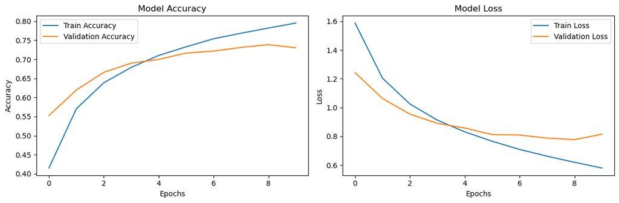

```python
plt.figure(figsize=(12, 4))
plt.subplot(1, 2, 1)
plt.plot(history.history['accuracy'], label='Train Accuracy')
plt.plot(history.history['val_accuracy'], label='Validation Accuracy')
plt.title('Model Accuracy')
plt.xlabel('Epochs')
plt.ylabel('Accuracy')
plt.legend()

plt.subplot(1, 2, 2)
plt.plot(history.history['loss'], label='Train Loss')
plt.plot(history.history['val_loss'], label='Validation Loss')
plt.title('Model Loss')
plt.xlabel('Epochs')
plt.ylabel('Loss')
plt.legend()

plt.tight_layout()
plt.show()
```